# Assignment 5

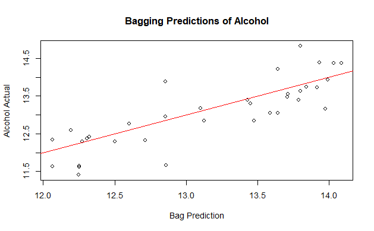

```r
plot(bagPred, testData$Alcohol, main = "Bagging Predictions of Alcohol", xlab = "Bag Prediction", ylab = "Alcohol Actual")
abline(0,1, col = "red")
```

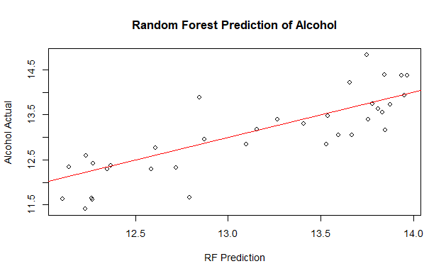

```r
plot(winePred, testData$Alcohol, main = "Random Forest Prediction of Alcohol", xlab = "RF Prediction", ylab = "Alcohol Actual")
abline(0,1, col = "red")
```

3. Evaluate a Bad Analysis:

*You are given a situation, identify as many problems as you can with the way it was handled and provide ideas for solutions. You do not need to fix this, you simply need to help the author know what happened and how they could make it better.*

Dr. Merl O. Tannin has come to you with a problem. His employee has submitted a report but Dr. Tannin doesn’t have time to read it with all the extra work he has going on from the oenology conference coming up. He has entrusted to you this report and wants feedback.Read the following report and state problems and fixes that need to be made:

Report: Predicting Alcohol Content using Linear Regression Author: Oakley Barrel

Data:

Model:

```r
Sub <- regsubsets(Alcohol~ ., data = Dat , nvmax = 13, method = "forward")
summary(Sub)
```

```
Subset selection object
Call: regsubsets.formula(Alcohol ~ ., data = Dat, nvmax = 13, method = "forward")
13 Variables  (and intercept)
                     Forced in Forced out
Malic_Acid               FALSE      FALSE
Ash                      FALSE      FALSE
Ash_Alcanity             FALSE      FALSE
Magnesium                FALSE      FALSE
Total_Phenols            FALSE      FALSE
Flavanoids               FALSE      FALSE
Nonflavanoid_Phenols     FALSE      FALSE
Proanthocyanins          FALSE      FALSE
Color_Intensity          FALSE      FALSE
Hue                      FALSE      FALSE
OD280                    FALSE      FALSE
Proline                  FALSE      FALSE
Customer_Segment         FALSE      FALSE
1 subsets of each size up to 13
Selection Algorithm: forward
          Malic_Acid Ash Ash_Alcanity Magnesium Total_Phenols Flavanoids Nonflavanoid_Phenols Proanthocyanins Color_Intensity Hue OD280 Proline Customer_Segment
1  ( 1 )  " "        " " " "          " "       " "           " "        " "                  " "             " "             " " " "   "*"     " "
2  ( 1 )  " "        " " " "          " "       " "           " "        " "                  " "             "*"             " " " "   "*"     " "
3  ( 1 )  " "        " " " "          " "       " "           " "        " "                  " "             "*"             " " " "   "*"     "*"
4  ( 1 )  "*"        " " " "          " "       " "           " "        " "                  " "             "*"             " " " "   "*"     "*"
5  ( 1 )  "*"        " " " "          " "       " "           " "        " "                  "*"             "*"             " " " "   "*"     "*"
6  ( 1 )  "*"        " " "*"          " "       " "           " "        " "                  "*"             "*"             " " " "   "*"     "*"
7  ( 1 )  "*"        " " "*"          " "       " "           "*"        " "                  "*"             "*"             " " " "   "*"     "*"
8  ( 1 )  "*"        " " "*"          " "       "*"           "*"        " "                  "*"             "*"             " " " "   "*"     "*"
9  ( 1 )  "*"        " " "*"          " "       "*"           "*"        "*"                  "*"             "*"             " " " "   "*"     "*"
10  ( 1 ) "*"        " " "*"          " "       "*"           "*"        "*"                  "*"             "*"             "*" " "   "*"     "*"
11  ( 1 ) "*"        "*" "*"          " "       "*"           "*"        "*"                  "*"             "*"             "*" " "   "*"     "*"
12  ( 1 ) "*"        "*" "*"          " "       "*"           "*"        "*"                  "*"             "*"             "*" "*"   "*"     "*"
13  ( 1 ) "*"        "*" "*"          "*"       "*"           "*"        "*"                  "*"             "*"             "*" "*"   "*"     "*"
```

```r
Reg <- lm(Alcohol ~ Magnesium + OD280, data = Dat)
summary(Reg)
```

```
Call:
lm(formula = Alcohol ~ Magnesium + OD280, data = Dat)

Residuals:
     Min       1Q   Median       3Q      Max
-1.80055 -0.53605  0.03349  0.59779  1.87474

Coefficients:
             Estimate Std. Error t value Pr(>|t|)
(Intercept) 11.322458   0.457473  24.750  < 2e-16 ***
Magnesium    0.015187   0.004139   3.670 0.000322 ***
OD280        0.062555   0.083254   0.751 0.453436
---
Signif. codes:  0 ‘***’ 0.001 ‘**’ 0.01 ‘*’ 0.05 ‘.’ 0.1 ‘ ’ 1

Residual standard error: 0.7847 on 175 degrees of freedom
Multiple R-squared:  0.07631,   Adjusted R-squared:  0.06576
F-statistic: 7.229 on 2 and 175 DF,  p-value: 0.0009627
```

> As you can see only Magnesium is important for evaluating Alcohol levels. The R squared is 0.076 which means it has captured about 92% of the variance and the intercept has the best t value so adjusting is the most important aspect to this model. The formula suggested for predicting Alcohol is:

$$Alcohol = \beta_0 + 0.015187Magnesium + 0.062555OD280$$

End Report

```r
summary(lm(Alcohol~ ., data = Dat))
```

```
Call:
lm(formula = Alcohol ~ ., data = Dat)

Residuals:
     Min       1Q   Median       3Q      Max
-1.25132 -0.31810 -0.00743  0.37385  1.58453

Coefficients:
                       Estimate Std. Error t value Pr(>|t|)
(Intercept)          12.6358720  0.7624038  16.574  < 2e-16 ***
Malic_Acid            0.1389050  0.0441476   3.146  0.00196 **
Ash                   0.0568030  0.2127036   0.267  0.78976
Ash_Alcanity         -0.0159968  0.0186593  -0.857  0.39253
Magnesium            -0.0002371  0.0032718  -0.072  0.94232
Total_Phenols         0.1201137  0.1322138   0.908  0.36496
Flavanoids           -0.1746787  0.1192302  -1.465  0.14482
Nonflavanoid_Phenols -0.3451894  0.4244582  -0.813  0.41726
Proanthocyanins      -0.1243457  0.0960666  -1.294  0.19736
Color_Intensity       0.1908659  0.0281304   6.785 2.01e-10 ***
Hue                   0.1309373  0.2750282   0.476  0.63465
OD280                 0.0186254  0.1158790   0.161  0.87250
Proline               0.0006123  0.0002327   2.631  0.00932 **
Customer_Segment     -0.4921658  0.1554729  -3.166  0.00185 **
---
Signif. codes:  0 ‘***’ 0.001 ‘**’ 0.01 ‘*’ 0.05 ‘.’ 0.1 ‘ ’ 1

Residual standard error: 0.522 on 164 degrees of freedom
Multiple R-squared:  0.617, Adjusted R-squared:  0.5866
F-statistic: 20.32 on 13 and 164 DF,  p-value: < 2.2e-16
```

> Notes:  
> - No use of train and test data for validation.  
> - Misunderstood how to read regsubsets. Magnesium is not important, it is actually the least important. To see importance it is read from top down so it would actually be Proline first, next Color_Intensity.  
> - Misunderstanding of R squared significance. 0.076 means 7.6% of the variance has been captured, not what was not captured.  
> - The intercept has nothing to do with the model in this case. It’s significance is simply a baseline for other predictors.  
> - Another point is that when comparing the subset lm and the full lm is that looking at the estimates, you can see how little magnesium actually affects the alcohol content compared to everything else. If anything, it might actually reduces the alcohol content given it has a negative estimate.  
> - Technically Magnesium is the most important, however, this is only in the context. Out of the two predictors used, Magnesium was the most important.  
> - To add on to the previous, if you ever make a claim, state what was used, for example. “Out of the two predictors used, Magnesium was much more significant…” This allows it to be more clear and less room for misinterpretation or misunderstanding.  
> - This is not so much an issue, but if you have the resources then use best subset selection. Forward selection classifies Proline as being the most significant yet it might not actually be the best due to the nature of forward step. For the best predictions then use best subset if plausible.